# Python course 2024

This first notebook illustrates some basic notions about variables and variable types, together with some basic manipolations and operations on them. The types of variables that are going to be considered are:

- integer (native python)
- float (native python)
- list (native python)
- tuple (native python)
- string (native python)
- array (numpy)
- boolean (native python)
- dictionary (native python)
- set (native python)

## Variable types

### *Native* Python

- *Assignment* of a *value* to a *variable*.
- The ' = ' symbol corresponds to the ***assignment instruction***.
- The assigned value determines the *type* of the variable being assigned

```python
a=1
print("Type of a:",type(a))

b=1.
print("Type of b:",type(b))
```

```
Type of a: <class 'int'>
Type of b: <class 'float'>
```

In the example above, *a* is an *integer variable*, whereas *b* is a *floating point variable*. They correspond to two different types.

- The command *type(variable)* provides the type of the *variable*
- <class 'int'>, as the response from *type(a)*, indicates that *a*, whose type is *integer*, is an instance of the *class* *int*. Such class has quite a number or *methods* (functions operating on instances of the class) that can be shown by using the command *help* on the name of the instance:

```python
help(a)
```

[output not shown]

[output cut: 135 more lines]

[output not shown]

Many of the methods of the class are so called *dunder* methods (*dunder* stands for *double underscore* __). They are *special* methods for performing the usual and most common operations on integer numbers. For instance, consider the simple addition operation of two integer numbers, one of which is stored in the variable *a* defined above, the other one being the number 2:

```python
a+2
```

```
3
```

Under the hood, this operation is performed by invoking the dunder method *add* that takes the value of the instance *a* and sums to it the value 2. The symbol '+' is associated with the *add method* implemented in the class and, indeed, the operation could be done by explicitly using such dunder method:

```python
a.__add__(2)
```

```
3
```

The *quotient* operation a/b is performed by the *truediv* dunder method; for instance, a/2 is equivalent to a.__truediv__(2):

```python
(a).__truediv__(2)
```

```
0.5
```

#### Type conversions

*a* is assigned as *integer*; the *float* function converts it into a *floating point number*:

```python
a=5
c=float(a)
print(a,"  type of a:", type(a))
print(c,"  type of c:", type(c))
```

```
5   type of a: <class 'int'>
5.0   type of c: <class 'float'>
```

#### Lists

List of integers

```python
d=[1,2,3,4]
print("Type of d:",type(d))
print(d[2]," type of an element of d:", type(d[2]))
```

```
Type of d: <class 'list'>
3  type of an element of d: <class 'int'>
```

```python
dir(d)  # dir makes a list of all the methods available for the class: in this case, the class 'list' to which the variable 'd' belongs
```

```
['__add__',
 '__class__',
 '__class_getitem__',
 '__contains__',
 '__delattr__',
 '__delitem__',
 '__dir__',
 '__doc__',
 '__eq__',
 '__format__',
 '__ge__',
 '__getattribute__',
 '__getitem__',
 '__getstate__',
 '__gt__',
 '__hash__',
 '__iadd__',
 '__imul__',
 '__init__',
 '__init_subclass__',
 '__iter__',
 '__le__',
 '__len__',
 '__lt__',
 '__mul__',
 '__ne__',
 '__new__',
 '__reduce__',
 '__reduce_ex__',
 '__repr__',
 '__reversed__',
 '__rmul__',
 '__setattr__',
 '__setitem__',
 '__sizeof__',
 '__str__',
 '__subclasshook__',
 'append',
 'clear',
 'copy',
 'count',
 'extend',
 'index',
 'insert',
 'pop',
 'remove',
 'reverse',
 'sort']
```

An example of *method* (not a *dunder method*) of the *list class*:

```python
d=[1,2,2,3,4,5,4,6,4]
d.count(4)
```

```
3
```

List of elements of different types:

```python
e=[1, "1", 1.]
print("Type of d:",type(d))

for ip in [0, 1, 2]:
    print(e[ip],"    - type of the element", ip, " of e:", type(e[ip]))
```

```
Type of d: <class 'list'>
1     - type of the element 0  of e: <class 'int'>
1     - type of the element 1  of e: <class 'str'>
1.0     - type of the element 2  of e: <class 'float'>
```

Elements of lists can be *reassigned*

```python
e[1]=2
print(e)
```

```
[1, 2, 1.0]
```

Note that the *index* of an *iterable* must be an integer number... otherwise you get an error:

```python
a=[0,1,2,3]
ip=1.

a[ip]
```

```
---------------------------------------------------------------------------
TypeError                                 Traceback (most recent call last)
Cell In[12], line 4
      1 a=[0,1,2,3]
      2 ip=1.
----> 4 a[ip]

TypeError: list indices must be integers or slices, not float
```

#### Tuples

```python
f=(1,2,3)
print(f, type(f))
```

```
(1, 2, 3) <class 'tuple'>
```

Elements of tuples *cannot be reassigned*... any attempt to reassign an element of a tuple results in a error:

```python
f[2]=4
```

```
---------------------------------------------------------------------------
TypeError                                 Traceback (most recent call last)
Cell In[14], line 1
----> 1 f[2]=4

TypeError: 'tuple' object does not support item assignment
```

#### Size of lists (and tuples)

```python
len(d)
```

```
9
```

```python
g=[[1,2,3,4],[5,6,7,8]]
```

```python
g
```

```
[[1, 2, 3, 4], [5, 6, 7, 8]]
```

```python
print(g[0])
print(g[1])
```

```
[1, 2, 3, 4]
[5, 6, 7, 8]
```

```python
print(len(g))
print(len(g[0]))
```

```
2
4
```

#### Strings

```python
h='this is a string'
print(h)
```

```
this is a string
```

```python
size=len(h)
ll=range(size)

print("Size of the string: ", size)
print("Type of ll:   ",type(ll),"\n\n")

for ip in ll:
    print(ip, h[ip])
```

```
Size of the string:  16
Type of ll:    <class 'range'>


0 t
1 h
2 i
3 s
4
5 i
6 s
7
8 a
9
10 s
11 t
12 r
13 i
14 n
15 g
```

#### Concatenation of lists (operator +)

```python
a="Statement_1"
b="statement_2"

c=a+" and "+b
print(c)
```

```
Statement_1 and statement_2
```

Note that the implementation of the '+' symbol of the class *string* (concatenates *strings*) is different from the implementation given for the *int* (or *float*) class.

The use of different implementations for the same symbol (indeed, *method* assigned to the symbol) is named *polymorphism*.

Here is the *concatenation* for numerical lists:

```python
a=[1,2,3]
b=[4,5]

c=a+b
print(c)
```

```
[1, 2, 3, 4, 5]
```

```python
c=[a]+[b]
print(c)
```

```
[[1, 2, 3], [4, 5]]
```

##### But...

```python
a=1
b=2

c=a+b
print(c)
```

```
3
```

where we assigned two integer variables (*a* and *b*) and summed them; in the following cell we convert those two variables in *strings*, by using the *str* function, and then we *sum* them by using the same symbol '+':

```python
a=str(a)
b=str(b)

c=a+b
print(c)
```

```
12
```

*tuples* and *list* can be *concatenated* by using the symbol '+', too:

```python
d=tuple([1,2]+[3,4])
e=tuple([1,2]) + tuple([3,4])
f=[1,2]+[3,4]

print(d, " - type d: ", type(d))
print(e, " - type e: ", type(e))
print(f, " - type f: ", type(f))
```

```
(1, 2, 3, 4)  - type d:  <class 'tuple'>
(1, 2, 3, 4)  - type e:  <class 'tuple'>
[1, 2, 3, 4]  - type f:  <class 'list'>
```

Note the difference between *d* and *e*: the results are the same, but in *d* we concatenated two lists and *converted* the final list in a *tuple*; in *e* we concatenated two tuples.

#### How to sum lists *element-wise* (*pure* Python)

In many cases you want to *sum* the elements of two lists *element-wise* (you don't want to *concatenate* the two lists).

You have a list $[a_1,\ldots,a_n]$ and a list $[b_1,\ldots,b_n]$, and you want the new list $[a_1+b_1,\ldots,a_n+b_n]$. In this case you have to write a few lines of code:

```python
a=[1,2,3,4,5]     # list a
b=[6,7,8,9,10]    # list b

c=[]              # prepare the empty list c
                  # that will contain the element-wise
                  # summation of a and b

la=len(a)         # length of list a
                  # b must have the same length of a

for ip in range(la):   # loop on the elements of the two lists
    isum=a[ip]+b[ip]   # sum of the variables a[ip] + b[ip]
    c.append(isum)     # the sum is appended to the list c

print(c)
```

```
[7, 9, 11, 13, 15]
```

In the code above, note the use of the *range* function to define a list of integers: if *la* is the length of the list *a*, *range(la)* will set up an *object* for the generation of the list $[0,1,\ldots,la-1]$

```python
la=5
rla=range(la)
list_la=list(rla)

print(rla, type(rla))
print(list_la)
```

```
range(0, 5) <class 'range'>
[0, 1, 2, 3, 4]
```

You see that *range(la)* is a new type of object: an object of type *range*.

Another method to sum lists element-wise, which is useful in the case the two lists have not the same length, makes use of the *zip* function:

```python
# Lists of same length

a=[1,2,3,4,5]
b=[6,7,8,9,10]
c=[]

for ia, ib in zip(a, b):
    isum=ia+ib
    c.append(isum)

print(c)
```

```
[7, 9, 11, 13, 15]
```

What if *a* and *b* are lists of different length?

```python
a=[1,2,3,4,5]
b=[6,7,8,9]
c=[]

for ia, ib in zip(a, b):
    isum=ia+ib
    c.append(isum)

print(c)
```

```
[7, 9, 11, 13]
```

Note that an error occurs if you try to sum lists of different length by using the first method shown above:

```python
a=[1,2,3,4,5]
b=[6,7,8,9]
c=[]

la=len(a)

for ip in range(la):
    isum=a[ip]+b[ip]
    c.append(isum)

print(c)
```

```
---------------------------------------------------------------------------
IndexError                                Traceback (most recent call last)
Cell In[34], line 8
      5 la=len(a)
      7 for ip in range(la):
----> 8     isum=a[ip]+b[ip]
      9     c.append(isum)
     11 print(c)

IndexError: list index out of range
```

The *zip* function sets up for the construction of a list obtained by *pair-wise* coupling the elements of the lists given as arguments to the function itself. Such coupling proceeds up to the end of the shortest list.

The result of *zip* is an object of the class *zip*.

```python
a=[1,2,3]
b=[10,11,12,14]

z=zip(a,b)
print(type(z))
print(list(z))
```

```
<class 'zip'>
[(1, 10), (2, 11), (3, 12)]
```

#### Sorting Python lists

```python
a=list([4,3,2,1])
print("Original list: ", a)

a.sort()
print("Sorted list:   ",a)
```

```
Original list:  [4, 3, 2, 1]
Sorted list:    [1, 2, 3, 4]
```

Note that this sorting operation is an *in-place* one: the original list is substituted by the sorted list (that is, the original list is *lost*...). Wanting to preserve the original list *a*, one may think that by creating a new variable *b* to store *a*, before the sorting, is enough to the purpose. But...

```python
a=list([4,3,2,1])
b=a
a.sort()
print(a)
print(b)
```

```
[1, 2, 3, 4]
[1, 2, 3, 4]
```

More on this behaviour in a later lecture... Just note here that the correct way to work in a case like this is:

```python
a=list([4,3,2,1])
b=a.copy()

a.sort()
print("Sorted list: ", a)
print("Original list: ", b)
```

```
Sorted list:  [1, 2, 3, 4]
Original list:  [4, 3, 2, 1]
```

where the method *copy* of the *class list* has been used to produce a new copy of the *a* list and stored in the variable *b*.

***Reverse*** sorting

```python
a=list([10, 3, 5, 6, 1, 8])
a.sort(reverse=True)
print(a)
```

```
[10, 8, 6, 5, 3, 1]
```

### Numpy

**Num**erical **Py**thon: one of the most important library (technically: a *module*) of Python

```python
import numpy as np   # import the numpy module with the 'np' alias

a=np.array([1,2,3,4,5])
print(a, "  - type of a", type(a))
```

```
[1 2 3 4 5]   - type of a <class 'numpy.ndarray'>
```

```python
print(len(a))   # size of a
```

```
5
```

... but *size* is also an *attribute* of *a*

```python
print(a.size)   # size is also an attribute of the array
```

```
5
```

... and *a* has also a *dtype* attribute:

```python
a.dtype
```

```
dtype('int32')
```

List of *attributes* and *methods* of a numpy array:

```python
help(a)
```

[output not shown]

[output cut: 1749 more lines]

[output not shown]

The type of an array can be forced to be different from the default. This is done by using the *dtype* keyword. For instance:

```python
a=np.array([1,2,3,4,5], dtype=np.int64)
print(a.dtype)
```

```
int64
```

```python
b=np.array([1,2,3,4,5], dtype=float)
print(b)
print(b.dtype)
```

```
[1. 2. 3. 4. 5.]
float64
```

Note that:

```python
c=np.array([1,2,3,4,5],dtype=str)
print(c)
```

```
['1' '2' '3' '4' '5']
```

#### Type conversion

```python
d=[1,2,3,4,5]
d_np=np.array(d, dtype=float)
print(d_np)
```

```
[1. 2. 3. 4. 5.]
```

```python
d_int64=np.int64(d)
d_int64
```

```
array([1, 2, 3, 4, 5], dtype=int64)
```

#### The elements of a numpy array must be of the same type

In case they are not, they are automatically converted into the appropriate type...

```python
a=np.array([1,'2.1',3.])
print(a)
```

```
['1' '2.1' '3.0']
```

#### Possible issues with *type* (*Advanced*)

Imagine that you have an integer variable $a$ that was assigned to the numer 2000, and that you have an integer variable $b$ set to 9. You want to calculate the power $a^b$, and then assign the result to the variable $c$: $c=a^b$

```python
a=2000
b=9
c=a**b   # **: a^b 'power' operation

c_bit_len=c.bit_length()  # number of bits employed to represent c

print("c: ", c, "type(c): ", type(c))
print("Number of bits required to represent c: ", c_bit_len)
```

```
c:  512000000000000000000000000000 type(c):  <class 'int'>
Number of bits required to represent c:  99
```

Note that *bit_length* is a method of the class *int*. Python has virtually no limits in representing integer numbers, as the number of bits (or bytes) required in each case is chosen at *runtime* accordingly. Now, imagine that you will instead *fix* such number of bits for representing your number (let's say *b*). You can do that within *numpy* by the method *dtype*. The way is not so straightfoward, anyway:

```python
# assign 9 to the variable b;
# b is a normal Python variable of int type
b=9

# convert the type of b to a 'int32' numpy type
b=np.dtype('int32').type(b)
print(b, type(b))
```

```
9 <class 'numpy.int32'>
```

Now, compute the power a^b:

```python
a**b
```

```
0
```

That is: a **completely wrong result!** That's because we got an *overflow*: the result of such computation is *forced* to be represented by an ***int32*** numpy number, but 32 bits are definitely not enough to do that... We verify that indeed

```python
type(a**b)
```

```
numpy.int32
```

whereas to represent a^b, at least 99 bits are required:

```python
a=2000
b=9
c=a**b
print(c.bit_length())
```

```
99
```

A *workaround* is, within numpy, to declare *b* to be of type *object*; this will not put limits to the dimension of the binary representation:

```python
b=np.dtype(object).type(b)

print(b, type(b))
print(a**b)
```

```
9 <class 'int'>
512000000000000000000000000000
```

Where does all this *really* matter?

Imagine that the exponents of your powers come from a numpy array which was initialized with just *zeroes*; then you assigned some integer numbers as elements of the array:

```python
b=np.array([0, 0, 0])
b[0]=1
b[1]=4
b[2]=9

print(type(b))
_ = [print(b[ip], type(b[ip])) for ip in range(3)]  # more on this syntax later...
```

```
<class 'numpy.ndarray'>
1 <class 'numpy.int32'>
4 <class 'numpy.int32'>
9 <class 'numpy.int32'>
```

As you can see, the type of the elements of the array *b* was automatically set to *int32*. Now, if you compute the sum $\sum_i a^{b_i}$, you are in trouble:

```python
sum_int=0
for ip in range(3):
    print("term n. ", ip," --> ", a**b[ip])
    sum_int=sum_int+a**b[ip]

print("\nTotal: ", sum_int)
```

```
term n.  0  -->  2000
term n.  1  -->  1246822400
term n.  2  -->  0

Total:  1246824400
```

which is a wrong result as the term number 2 is clearly in overflow. A way to proceed to get a correct result is:

```python
b=np.array([0, 0, 0])
b[0]=1
b[1]=4
b[2]=9

b=np.dtype(object).type(b)

print(type(b))
_ = [print(b[ip], type(b[ip])) for ip in range(3)]

sum_int=0
for ip in range(3):
    print("term n. ", ip," --> ", a**b[ip])
    sum_int=sum_int+a**b[ip]

print("\nTotal: ", sum_int)
```

```
<class 'numpy.ndarray'>
1 <class 'int'>
4 <class 'int'>
9 <class 'int'>
term n.  0  -->  2000
term n.  1  -->  16000000000000
term n.  2  -->  512000000000000000000000000000

Total:  512000000000000016000000002000
```

Another way is to convert *a* to a *float number*, so that *a^b* is also represented as a *float* no matter the type of *b*:

```python
b=np.array([0, 0, 0])
b[0]=1
b[1]=4
b[2]=9

a=float(a)

sum_float=0.
for ip in range(3):
    print("term n. ", ip," --> ", a**b[ip])
    sum_float=sum_float+a**b[ip]

print("\nTotal: %4.30e" % sum_float)
```

```
term n.  0  -->  2000.0
term n.  1  -->  16000000000000.0
term n.  2  -->  5.12e+29

Total: 5.120000000000000068032281968640e+29
```

Note however the difference between the integer *sum_int* and float *sum_float* variables...

Below is a test (==) that returns a *boolean* variable (*True* or *False*) that will be discussed later:

```python
print(sum_int == sum_float)
```

```
False
```

That is, they do not have the very same value. This has to do with the *integer to float* conversion (floating point numbers are represented at most by 64 bits, but our integer variables require 99 bits); indeed, if we convert to a float number the original integer *sum_int*:

```python
print(float(sum_int) == sum_float)
```

```
True
```

Note that in case a much smaller number is considered, let's say 20, there is no difference in *value* between the floating point and integer representations:

```python
t1=20
t2=20.

print(t1 == t2)
```

```
True
```

Nevertheless *t1* and *t2* are not the same variable: they may have the same *value*, but their types are different:

```python
t1 is t2  # test if the two variables are the same
```

```
False
```

#### Summing numpy arrays *element-wise* is very easy... (arrays must have the same size)

```python
a=np.array([1,2,3,4])
b=np.array([5,6,7,8])

c=a+b
print(c)
```

```
[ 6  8 10 12]
```

Instead, to *concatenate* the two arrays, the *append* numpy function can be used:

```python
c=np.append(a,b)
print(c)
```

```
[1 2 3 4 5 6 7 8]
```

Another method to concatenate two (or more) arrays is to use the numpy function *concatenate*

```python
print(np.concatenate((a,b)))
```

```
[1 2 3 4 5 6 7 8]
```

#### Broadcasting

Applying an operation (*element-wise*) to all the elements of a numpy array

```python
a=np.array([0,1,2,3,4])
b=a*10

print("a: ", a)
print("b: ", b)
```

```
a:  [0 1 2 3 4]
b:  [ 0 10 20 30 40]
```

Likewise, even a sum can be *broadcasted*:

```python
a=np.array([0,1,2,3,4])
b=a+10

print("a: ", a)
print("b: ", b)
```

```
a:  [0 1 2 3 4]
b:  [10 11 12 13 14]
```

Note that *broadcasting* doesn't work for python lists (indeed, it operates in a different way...). Eg.:

```python
a=[1,2,3,4]
a*2
```

```
[1, 2, 3, 4, 1, 2, 3, 4]
```

that is: the list is repead twice.

As already seen above, in the case of Python lists, to perform an operation which is equivalent to the numpy broadcasting, some few lines of code must be written:

```python
for ia in range(len(a)):
    a[ia]=2*a[ia]

print(a)
```

```
[2, 4, 6, 8]
```

#### Attributes of numpy arrays

```python
a=np.array([0,1,2,3,4])

print("Size:      ", a.size)
print("Type:      ", a.dtype)
print("Shape:     ", a.shape)
print("Dimension: ", a.ndim)
```

```
Size:       5
Type:       int32
Shape:      (5,)
Dimension:  1
```

```python
a=np.array([[1,2,3,4],[5,6,7,8]], dtype=np.float64)
print(a)

print("\nSize:      ", a.size)
print("Type:      ", a.dtype)
print("Shape:     ", a.shape)
print("Dimension: ", a.ndim)
```

```
[[1. 2. 3. 4.]
 [5. 6. 7. 8.]]

Size:       8
Type:       float64
Shape:      (2, 4)
Dimension:  2
```

Getting the elements of an array

```python
print(a[0])    # print line 0
print(a[1,2])  # print the element in line 1 and column 2
print(a[1][2]) # as above... print the element 2 of line 1
```

```
[1. 2. 3. 4.]
7.0
7.0
```

#### Array methods

```python
a=a.reshape(4,2)

print(a)

print("\nSize:  ", a.size)
print("Type:  ", a.dtype)
print("Shape: ", a.shape)
```

```
[[1. 2.]
 [3. 4.]
 [5. 6.]
 [7. 8.]]

Size:   8
Type:   float64
Shape:  (4, 2)
```

```python
a.transpose()
```

```
array([[1., 3., 5., 7.],
       [2., 4., 6., 8.]])
```

```python
a=a.flatten()
```

```python
print("Array:     ", a)
print("Max:       ", a.max())
print("Min:       ", a.min())
print("Mean:      ", a.mean())
print("Dimension: ", a.ndim)
```

```
Array:      [1. 2. 3. 4. 5. 6. 7. 8.]
Max:        8.0
Min:        1.0
Mean:       4.5
Dimension:  1
```

#### Slicing

```python
a=list(range(10))   # a Python list (it is not a numpy array)
print(a)
```

```
[0, 1, 2, 3, 4, 5, 6, 7, 8, 9]
```

```python
print(a[1:5])  # n:m[:s] start, end, [step]
print(a[5:-1])
print(a[::2])
print(a[1::2])
```

```
[1, 2, 3, 4]
[5, 6, 7, 8]
[0, 2, 4, 6, 8]
[1, 3, 5, 7, 9]
```

```python
a=np.array([[0,1,2,3,4,5],[6,7,8,9,10,11]])
print(a)
```

```
[[ 0  1  2  3  4  5]
 [ 6  7  8  9 10 11]]
```

Get the second row (row index 1) of the array:

```
a[1,:]
```

```python
print(a[1,:])
```

```
[ 6  7  8  9 10 11]
```

Get the third colums (index 2) of the array

```python
print(a[:,2])
```

```
[2 8]
```

#### Sorting numpy arrays

```python
a=np.array([1,3,5,2,8,7,6,9,4])
print("Original array: ", a)

a.sort()
print("Sorted array:   ", a)
```

```
Original array:  [1 3 5 2 8 7 6 9 4]
Sorted array:    [1 2 3 4 5 6 7 8 9]
```

Note in the following the use of the *np.sort* function:

```python
a=np.array([1,3,5,2,8,7,6,9,4])
print("Original array: ", a)
print("Sorted array:   ", np.sort(a))
print("Original array is not modified: ", a)
```

```
Original array:  [1 3 5 2 8 7 6 9 4]
Sorted array:    [1 2 3 4 5 6 7 8 9]
Original array is not modified:  [1 3 5 2 8 7 6 9 4]
```

Note that, at variance with the sort method of the python lists, the original array is preserved.

***Reverse*** ordering

This exploits a slicing of a (*normal*) sorted array

```python
a=np.array([3,2,1,5,9,8,6,7])
a_reverse=np.sort(a)[::-1]

print("Reverse sorting: ", a_reverse)
```

```
Reverse sorting:  [9 8 7 6 5 3 2 1]
```

Numpy function *argsort*: this returns the *positions* of the elements in the array, from the minimum to the maximum values:

```python
a=np.array([1,3,5,2,8,7,6,9,4])
pos=np.argsort(a)
print("Positions: ", pos)
```

```
Positions:  [0 3 1 8 2 6 5 4 7]
```

The *pos* array can then be used to draw elements from the original array, for instance to sort it:

```python
print("Sorted array: ", a[pos])
```

```
Sorted array:  [1 2 3 4 5 6 7 8 9]
```

#### Using argsort to sort a 2-dimensional array

Here we sort a (2,6)-array according to the elements of the first row

```python
a=np.array([[5, 3, 1, 0, 4, 2], [25, 9, 1, 0, 16, 4]])
print(a)
```

```
[[ 5  3  1  0  4  2]
 [25  9  1  0 16  4]]
```

```python
print("First row: ", a[0,:])  # print the first row (index 0)

pos=np.argsort(a[0,:])        # positions of the elements from min to max
print("Positions: ", pos)

a1=a[0,pos]
a2=a[1,pos]

a_sorted=np.concatenate(([a1], [a2]))
print("Sorted array:\n", a_sorted)
```

```
First row:  [5 3 1 0 4 2]
Positions:  [3 2 5 1 4 0]
Sorted array:
 [[ 0  1  2  3  4  5]
 [ 0  1  4  9 16 25]]
```

#### Minimum and maximum of an array

```python
a=np.array([1,3,5,2,8,7,6,9,4])

a_min=np.min(a)
a_min_pos=np.argmin(a)

a_max=np.max(a)
a_max_pos=np.argmax(a)

print("Minimum of a: ", a_min, "   - position: ", a_min_pos)
print("Maximum of a: ", a_max, "   - position: ", a_max_pos)
```

```
Minimum of a:  1    - position:  0
Maximum of a:  9    - position:  7
```

#### A simple example: findind the minimum of a simple function in a specified X range

$y(x)=2x^4-11x^3+10x^2-3x+90$

```
X at which Y is minimum:   3.44
Value of Y at the minimum: 30.31
```

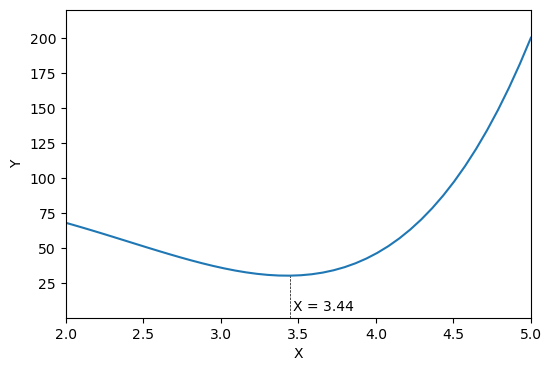

```python
# Import the "plotting library"
import matplotlib.pyplot as plt

# Create a list of 100 floating point numbers, from
# -2. to 5.
x=np.linspace(-2,5.0,100)

# Create a list of numbers y, by evaluating
# the expression below for all the values in
# the list x (this is an example of
# broadcasting)
y=2*x**4-11*x**3+10*x**2-3*x+90

y_min=np.min(y)
y_min_pos=np.argmin(y)
x_min=x[y_min_pos]

print("X at which Y is minimum:   %3.2f" % x_min)
print("Value of Y at the minimum: %3.2f\n" % y_min)

y0=y_min-30
px=(x_min,x_min)
py=(y0,y_min)

plt.figure(figsize=(6,4))
plt.plot(x,y)
plt.plot(px,py,"k--", linewidth=0.5 )
plt.xlabel("X")
plt.ylabel("Y")
plt.ylim(y0,220)
plt.xlim(2,5)
plt.text(x_min+0.02, y0+5, "X = " + str(x_min.round(2)))
plt.show()
```

#### Copies of a numpy array

Let's have an array *a*, in this case generated by the numpy function *arange* (it produces a list of integers):

```python
a=np.arange(10)
print(a)
```

```
[0 1 2 3 4 5 6 7 8 9]
```

We could *think* to get a copy (*b*) of our original array *a*, so that we can modify *a* but preserving a *backup copy* of it saved in *b*...

```python
b=a
print("Backup b:   ", b)

a[2], a[4] = 4, 2

print("Modified a: ", a)
```

```
Backup b:    [0 1 2 3 4 5 6 7 8 9]
Modified a:  [0 1 4 3 2 5 6 7 8 9]
```

But... let's have a look to *b*, now:

```python
print("array b: ", b)
```

```
array b:  [0 1 4 3 2 5 6 7 8 9]
```

So: we don't have our backup... as *a* and *b* are the same object:

```python
print(a is b)
```

```
True
```

Indeed, *a* and *b* are just *labels* that point to the same location in memory... To make a *real* copy of the array *a*, the numpy function *copy* must be used:

```python
a=np.arange(10)
b=np.copy(a)

print("Are 'a' and 'b' the same objects? %r\n " % (a is b))

a[2], a[4] = 4, 2
print("Modified array a: ", a)
print("Backup array b:   ", b)
```

```
Are 'a' and 'b' the same objects? False

Modified array a:  [0 1 4 3 2 5 6 7 8 9]
Backup array b:    [0 1 2 3 4 5 6 7 8 9]
```

The same is true for Python lists. In this case, to copy a list use the method *copy* associated to the list (that was already seen above):

```python
a=[0,1,2,3]
b=a.copy()

a[0]=5

print("List a: ", a, "   List b:  ", b)
```

```
List a:  [5, 1, 2, 3]    List b:   [0, 1, 2, 3]
```

Let's have a look at the positions in memory of the three *a*, *b* and *c* objects:

```python
a=[1,2,3,4]
b=a
c=a.copy()

print(hex(id(a)))
print(hex(id(b)))
print(hex(id(c)))
```

```
0x1ce06934f00
0x1ce06934f00
0x1ce06934fc0
```

Objects *a* and *b* do occupy the same position in memory: they are the *same* object, just having two different *labels* (*a* and *b*); object *c* occupies a different position.

We should distinguish the *address* of a list *versus* the *addresses* of the elements of the list:

```python
a=[0, 1, 2, 3, 4]

print("Address of a: ", hex(id(a)), "\n")

print("Addresses of the elements of a:")
for ia in range(len(a)):
    print(hex(id(a[ia])))
```

```
Address of a:  0x1ce066d3e40

Addresses of the elements of a:
0x7ffbe2a79308
0x7ffbe2a79328
0x7ffbe2a79348
0x7ffbe2a79368
0x7ffbe2a79388
```

As in the case of lists, a given value can be assigned to multiple labels (variable *names*); such *names* point to the same location in memory where the value is stored.

However, when one of the variable (label) is reassigned, the position in memory to which it points is changed:

```python
# the value 1 is assigned to o1, and then o1 is assigned to o2
# o1 and o2 points to the same address
o1=1
o2=o1

print(hex(id(o1)))
print(hex(id(o2)))
```

```
0x7ffbe2a79328
0x7ffbe2a79328
```

```python
# Now o1 is reassigned;
# o2 still preserves the original value;
# o1 points to a different location in memory

o1=2

print(o1, o2)
print(hex(id(o1)))
print(hex(id(o2)))
```

```
2 1
0x7ffbe2a79348
0x7ffbe2a79328
```

#### Special numpy arrays

It is possible to create arrays of 0's or 1's by using the numpy functions *zeros* and *ones*:

```python
a=np.zeros(10)
b=np.ones((3,3))

print("a: ", a)
print("\nb:\n", b)
```

```
a:  [0. 0. 0. 0. 0. 0. 0. 0. 0. 0.]

b:
 [[1. 1. 1.]
 [1. 1. 1.]
 [1. 1. 1.]]
```

The functions *repeat* and *tile* are also useful:

```python
a=np.repeat(2,5)
b=np.repeat([1,2,3],3)
c=np.tile([1,2,3],3)

print("a: ", a)
print("b: ", b)
print("c: ", c)
```

```
a:  [2 2 2 2 2]
b:  [1 1 1 2 2 2 3 3 3]
c:  [1 2 3 1 2 3 1 2 3]
```

### Boolean variables

```python
a, b = True, False
print("Type of a: ", type(a))
```

```
Type of a:  <class 'bool'>
```

#### Operators *and* (&) and *or* (|)

```python
print(a and b)
print(a & b)
```

```
False
False
```

```python
print(a or b)
print(a | b)
```

```
True
True
```

However...

```python
a=[True, True]
b=[True, False]

print(a and b)
```

```
[True, False]
```

but you get an error with &...

```python
print(a & b)
```

```
---------------------------------------------------------------------------
TypeError                                 Traceback (most recent call last)
Cell In[109], line 1
----> 1 print(a & b)

TypeError: unsupported operand type(s) for &: 'list' and 'list'
```

The same is true for the *or* operator (use *or*, and not the *pipe* |, to work with lists)

Boolean arrays can also be created by using a list of 0 and 1 (and dtype=bool):

```python
tf=np.array([1,1,0,1,1,0], dtype=bool)
tf
```

```
array([ True,  True, False,  True,  True, False])
```

#### *** Warning ***

**With numpy array it is different!**

```python
a=np.repeat(True, 3)
b=np.array([True, False, True])

a_and_b = a & b
print(a_and_b)
```

```
[ True False  True]
```

But...

```python
a_and_b = a and b
```

```
---------------------------------------------------------------------------
ValueError                                Traceback (most recent call last)
Cell In[112], line 1
----> 1 a_and_b = a and b

ValueError: The truth value of an array with more than one element is ambiguous. Use a.any() or a.all()
```

#### Using booleans to select elements of an array

```python
a=np.arange(10, 20)
select=np.tile([True, False], 5)
print("Array a:           ", a)
print("Boolean array:     ", select)
print("Selected elements: ", a[select])
```

```
Array a:            [10 11 12 13 14 15 16 17 18 19]
Boolean array:      [ True False  True False  True False  True False  True False]
Selected elements:  [10 12 14 16 18]
```

#### Boolean variables as result of *test*

```python
a=3
b=2

test1 = a > b
test2 = a < b
test3 = a == b
test4 = a != b

test_list=[test1, test2, test3, test4]

print(test_list)
```

```
[True, False, False, True]
```

#### Using a test to select elements of an array

```python
a=np.arange(10, 20)
thr=14

test = a >= thr
print(a[test])
```

```
[14 15 16 17 18 19]
```

A shorthand...

```python
print(a[a>=thr])
```

```
[14 15 16 17 18 19]
```

Another method, using the numpy function *where*

```python
np.where(a >= thr)
```

```
(array([4, 5, 6, 7, 8, 9], dtype=int64),)
```

```python
b=np.where(a >= thr)
print(a[b])
```

```
[14 15 16 17 18 19]
```

### Intersection and union of arrays

```python
a=np.arange(0,10)
b=np.arange(5,15)

a_int_b=np.intersect1d(a,b)
a_uni_b=np.union1d(a,b)

print("Intersection: ", a_int_b)
print("Union:        ", a_uni_b)
```

```
Intersection:  [5 6 7 8 9]
Union:         [ 0  1  2  3  4  5  6  7  8  9 10 11 12 13 14]
```

### Dictionaries

Used to assign values to strings that, later, can be used as indexes to retrieve the corrisponding values in the dictionary

```python
dct={'var1': 1.0, 'var2': 1.5, 'var3': 'my_var'}

print(type(dct), " length: ", len(dct), "\n")
print("var1: ", dct['var1'])
print("var3: ", dct['var3'])

print("\nWhole dictionary: ", dct)
```

```
<class 'dict'>  length:  3

var1:  1.0
var3:  my_var

Whole dictionary:  {'var1': 1.0, 'var2': 1.5, 'var3': 'my_var'}
```

### Sets

```python
set_list=[1,2,3,4,2,0,1]
s1=set(set_list)
print(type(s1), s1)
```

```
<class 'set'> {0, 1, 2, 3, 4}
```

```python
help(s1)
```

[output not shown]

[output cut: 58 more lines]

[output not shown]

```python
s2=set([1,3,10,11,12])
print("Intersection: ", s2.intersection(s1))
print("Union: ", s2.union(s1))
print("Difference: ", s2.difference(s1))
```

```
Intersection:  {1, 3}
Union:  {0, 1, 2, 3, 4, 10, 11, 12}
Difference:  {10, 11, 12}
```